# temp-164913338615028490

[figure not shown]

```python
import numpy as np
import pandas as pd
import seaborn as sns
import matplotlib.pyplot as plt

import warnings
warnings.filterwarnings(action = 'ignore')
```

```python
df = pd.read_csv('C:/Users/acer/Documents/Swiggy Bangalore Outlet Details.csv')
```

```python
df
```

|  | Shop_Name | Cuisine | Location | Rating | Cost_for_Two |
| --- | --- | --- | --- | --- | --- |
| 0 | Kanti Sweets | Sweets | Koramangala, Koramangala | 4.3 | ₹ 150 |
| 1 | Mumbai Tiffin | North Indian, Home Food, Thalis, Combo | Sector 5, HSR | 4.4 | ₹ 400 |
| 2 | Sri Krishna sagar | South Indian, North Indian, Fast Food, Beverag... | 6th Block, Koramangala | 4.1 | ₹ 126 |
| 3 | Al Daaz | American, Arabian, Chinese, Desserts, Fast Foo... | HSR, HSR | 4.4 | ₹ 400 |
| 4 | Beijing Bites | Chinese, Thai | 5th Block, Koramangala | 4.1 | ₹ 450 |
| ... | ... | ... | ... | ... | ... |
| 113 | Wok Paper Scissors | Pan-Asian, Chinese, Asian | JNC Road, Koramangala | 3.9 | ₹ 219 |
| 114 | Savoury Restaurant | Arabian, Middle Eastern, North Indian, Grill, ... | Madiwala, BTM | 4.1 | ₹ 600 |
| 115 | Royal Treat | North Indian, Chinese, Seafood, Biryani | 5th block Koramangala, Koramangala | 4.2 | ₹ 193 |
| 116 | Thali 99 | North Indian | Koramangala, Koramangala | 4.3 | ₹ 200 |
| 117 | Mani's Dum Biryani | Andhra, Biryani | 1st Block, Koramangala | 4.2 | ₹ 400 |

118 rows × 5 columns

```python
ind = df[df['Rating'] == '--'].index
ind
```

```
Int64Index([98], dtype='int64')
```

```python
df.loc[ind,'Rating'] = 0
```

```python
df['Rating'] = df['Rating'].astype('float')
```

```python
df.info()
```

```
<class 'pandas.core.frame.DataFrame'>
RangeIndex: 118 entries, 0 to 117
Data columns (total 5 columns):
 #   Column        Non-Null Count  Dtype
---  ------        --------------  -----
 0   Shop_Name     118 non-null    object
 1   Cuisine       118 non-null    object
 2   Location      118 non-null    object
 3   Rating        118 non-null    float64
 4   Cost_for_Two  118 non-null    object
dtypes: float64(1), object(4)
memory usage: 4.7+ KB
```

```python
obj = lambda x: x[1:]
```

```python
df['Cost_for_Two'] = df['Cost_for_Two'].apply(obj).astype('int32')
```

```python
df.info()
```

```
<class 'pandas.core.frame.DataFrame'>
RangeIndex: 118 entries, 0 to 117
Data columns (total 5 columns):
 #   Column        Non-Null Count  Dtype
---  ------        --------------  -----
 0   Shop_Name     118 non-null    object
 1   Cuisine       118 non-null    object
 2   Location      118 non-null    object
 3   Rating        118 non-null    float64
 4   Cost_for_Two  118 non-null    int32
dtypes: float64(1), int32(1), object(3)
memory usage: 4.3+ KB
```

```python
df.columns
```

```
Index(['Shop_Name', 'Cuisine', 'Location', 'Rating', 'Cost_for_Two'], dtype='object')
```

```python
df.describe()
```

|  | Rating | Cost_for_Two |
| --- | --- | --- |
| count | 118.000000 | 118.000000 |
| mean | 4.061864 | 321.008475 |
| std | 0.430845 | 137.286804 |
| min | 0.000000 | 100.000000 |
| 25% | 4.000000 | 204.750000 |
| 50% | 4.100000 | 300.000000 |
| 75% | 4.300000 | 400.000000 |
| max | 4.800000 | 800.000000 |

# Observation

1-> Mean Rating for Swiggy is 4.061 which is good for Customers.

2-> Average Cost for two person is approximately 321 rupees.

3-> Max Rating and Cost for two is 4.8 and 800 rupees respectively.

```python
#Shops that have minimum cost and maximum rating
```

```python
df.sort_values(by='Rating', ascending=False).head()
```

|  | Shop_Name | Cuisine | Location | Rating | Cost_for_Two |
| --- | --- | --- | --- | --- | --- |
| 78 | Khichdi Experiment | Home Food, Healthy Food, Indian | Koramangala, Koramangala | 4.8 | 200 |
| 94 | Corner House Ice Cream | Ice Cream, Desserts | 7th Block, Koramangala | 4.6 | 250 |
| 82 | Natural Ice Cream | Ice Cream | Near Wipro Park Signal, Koramangala | 4.6 | 150 |
| 80 | Chinese Bae | Chinese, Thai | BTM, BTM | 4.5 | 450 |
| 3 | Al Daaz | American, Arabian, Chinese, Desserts, Fast Foo... | HSR, HSR | 4.4 | 400 |

```python
df.sort_values(by='Cost_for_Two').head()
```

|  | Shop_Name | Cuisine | Location | Rating | Cost_for_Two |
| --- | --- | --- | --- | --- | --- |
| 79 | Tandoori Merchant | Andhra, Biryani, Chinese, Desserts, Fast Food,... | 4th Cross, BTM | 4.2 | 100 |
| 89 | 99 VARIETY DOSA AND JUICE-Malli mane food court | Fast Food, Juices, North Indian | Koramangala 1st block, Koramangala | 4.1 | 100 |
| 95 | NIC Natural Ice Creams | Ice Cream, Desserts | Koramangla, Koramangala | 4.2 | 120 |
| 2 | Sri Krishna sagar | South Indian, North Indian, Fast Food, Beverag... | 6th Block, Koramangala | 4.1 | 126 |
| 21 | Maa Di Hatti | Chinese, Healthy Food, North Indian | Jakkasandra Extn, Koramangala | 4.0 | 129 |

# Observation

1-> Most liked food is from Khichdi Experiment which have Home Food, Healthy Food, Indian cuisines and have highest rating of 4.8

2-> Ice cream business is more liked in Koramangala

```python
df
```

|  | Shop_Name | Cuisine | Location | Rating | Cost_for_Two |
| --- | --- | --- | --- | --- | --- |
| 0 | Kanti Sweets | Sweets | Koramangala, Koramangala | 4.3 | 150 |
| 1 | Mumbai Tiffin | North Indian, Home Food, Thalis, Combo | Sector 5, HSR | 4.4 | 400 |
| 2 | Sri Krishna sagar | South Indian, North Indian, Fast Food, Beverag... | 6th Block, Koramangala | 4.1 | 126 |
| 3 | Al Daaz | American, Arabian, Chinese, Desserts, Fast Foo... | HSR, HSR | 4.4 | 400 |
| 4 | Beijing Bites | Chinese, Thai | 5th Block, Koramangala | 4.1 | 450 |
| ... | ... | ... | ... | ... | ... |
| 113 | Wok Paper Scissors | Pan-Asian, Chinese, Asian | JNC Road, Koramangala | 3.9 | 219 |
| 114 | Savoury Restaurant | Arabian, Middle Eastern, North Indian, Grill, ... | Madiwala, BTM | 4.1 | 600 |
| 115 | Royal Treat | North Indian, Chinese, Seafood, Biryani | 5th block Koramangala, Koramangala | 4.2 | 193 |
| 116 | Thali 99 | North Indian | Koramangala, Koramangala | 4.3 | 200 |
| 117 | Mani's Dum Biryani | Andhra, Biryani | 1st Block, Koramangala | 4.2 | 400 |

118 rows × 5 columns

# Finding Shop name According to our cuisine need

```python
'''s = input("Enter the Cuisine you want : ")
str = s.lower()
c = 0
for ind,val in enumerate(df.Cuisine):
    j = val.lower()
    if(str in j):
        print(df.iloc[ind,0])
        c +=1
print(c)
'''
```

```
's = input("Enter the Cuisine you want : ")\nstr = s.lower()\nc = 0\nfor ind,val in enumerate(df.Cuisine):\n    j = val.lower()\n    if(str in j):\n        print(df.iloc[ind,0])\n        c +=1\nprint(c)\n'
```

```python
df
```

|  | Shop_Name | Cuisine | Location | Rating | Cost_for_Two |
| --- | --- | --- | --- | --- | --- |
| 0 | Kanti Sweets | Sweets | Koramangala, Koramangala | 4.3 | 150 |
| 1 | Mumbai Tiffin | North Indian, Home Food, Thalis, Combo | Sector 5, HSR | 4.4 | 400 |
| 2 | Sri Krishna sagar | South Indian, North Indian, Fast Food, Beverag... | 6th Block, Koramangala | 4.1 | 126 |
| 3 | Al Daaz | American, Arabian, Chinese, Desserts, Fast Foo... | HSR, HSR | 4.4 | 400 |
| 4 | Beijing Bites | Chinese, Thai | 5th Block, Koramangala | 4.1 | 450 |
| ... | ... | ... | ... | ... | ... |
| 113 | Wok Paper Scissors | Pan-Asian, Chinese, Asian | JNC Road, Koramangala | 3.9 | 219 |
| 114 | Savoury Restaurant | Arabian, Middle Eastern, North Indian, Grill, ... | Madiwala, BTM | 4.1 | 600 |
| 115 | Royal Treat | North Indian, Chinese, Seafood, Biryani | 5th block Koramangala, Koramangala | 4.2 | 193 |
| 116 | Thali 99 | North Indian | Koramangala, Koramangala | 4.3 | 200 |
| 117 | Mani's Dum Biryani | Andhra, Biryani | 1st Block, Koramangala | 4.2 | 400 |

118 rows × 5 columns

```python
df['Location'].unique()
```

```
array(['Koramangala, Koramangala', 'Sector 5, HSR',
       '6th Block, Koramangala', 'HSR, HSR', '5th Block, Koramangala',
       'Koramangala 4th  Block, Koramangala', 'BTM 2nd Stage, BTM',
       'BTM, BTM', '9th Main road, Koramangala', 'outer ring road, BTM',
       '7th Block, Koramangala', '1st MAin, Koramangala',
       'Bommanahalli, BTM', '6th block, Koramangala', 'Sector 4, HSR',
       'BTM 1st stage, BTM', 'Jakkasandra Extn, Koramangala',
       'Marutinagar Main Road, BTM', '1st Block, Koramangala',
       '4th Cross, BTM', 'koramangala, Koramangala', 'BTM 2nd stage, BTM',
       '3rd main, BTM', 'HSR 1st sector, HSR', 'Sector 7, HSR',
       '3rd Sector, HSR', 'Chocolate Factory Road, BTM',
       '16th Main Road, 2nd Stage, BTM', '1st Stage, BTM',
       'Hosur Main Road, Koramangala',
       '1st Cross Road, 5th Block, Near Jyothi Nivas College, Koramangala',
       'Mico Layout, BTM', '4th Cross, Koramangala',
       '4th Block, Koramangala', 'Intermediate Ring Road, Koramangala',
       '3rd sector, HSR', '8TH BLOCK, Koramangala',
       '4th b cross, Koramangala', 'SG palaya, BTM',
       "Venkatapura Main Rd, Teacher's Colony, Jakkasandra, HSR",
       'KHB Colony, Koramangala', 'Sector 3, HSR',
       'Bannerghatta Road, Jayanagar',
       '80 Feet Peripheral Road, Koramangala', 'Btm, BTM',
       'Near Wipro Park Signal, Koramangala', '16th Main Road, BTM',
       '2nd Stage, BTM', 'Kuvempu Nagar, Stage 2, BTM',
       'Koramangala 1st block, Koramangala',
       '5th Block Kormangala, Koramangala', 'Koramangla, Koramangala',
       '5th block, Koramangala', '9th Main Rd, Sector 6, HSR Layout, HSR',
       'Jay Bheema Nagar, BTM', 'Koramangala 6th block, Koramangala',
       'Maruthi Nagar, BTM', 'Sector 6, HSR',
       'Jakkasandra Village, Koramangala', '4th block, Koramangala',
       'Madiwala Junction, BTM', 'kormangala, Koramangala',
       'JNC Road, Koramangala', 'Madiwala, BTM',
       '5th block Koramangala, Koramangala'], dtype=object)
```

```python
a=df['Location'].str.split(pat=',',expand=True)
a
```

|  | 0 | 1 | 2 | 3 |
| --- | --- | --- | --- | --- |
| 0 | Koramangala | Koramangala | None | None |
| 1 | Sector 5 | HSR | None | None |
| 2 | 6th Block | Koramangala | None | None |
| 3 | HSR | HSR | None | None |
| 4 | 5th Block | Koramangala | None | None |
| ... | ... | ... | ... | ... |
| 113 | JNC Road | Koramangala | None | None |
| 114 | Madiwala | BTM | None | None |
| 115 | 5th block Koramangala | Koramangala | None | None |
| 116 | Koramangala | Koramangala | None | None |
| 117 | 1st Block | Koramangala | None | None |

118 rows × 4 columns

```python
b=df['Location'].str.split(pat=',').reset_index()
b
```

|  | index | Location |
| --- | --- | --- |
| 0 | 0 | [Koramangala, Koramangala] |
| 1 | 1 | [Sector 5, HSR] |
| 2 | 2 | [6th Block, Koramangala] |
| 3 | 3 | [HSR, HSR] |
| 4 | 4 | [5th Block, Koramangala] |
| ... | ... | ... |
| 113 | 113 | [JNC Road, Koramangala] |
| 114 | 114 | [Madiwala, BTM] |
| 115 | 115 | [5th block Koramangala, Koramangala] |
| 116 | 116 | [Koramangala, Koramangala] |
| 117 | 117 | [1st Block, Koramangala] |

118 rows × 2 columns

```python
obj1 = lambda x: x[-1]
```

```python
b['Location'] = b['Location'].apply(obj1)
```

```python
b.rename({'Location': 'City Name'},axis=1,inplace=True)
```

```python
b
```

|  | index | City Name |
| --- | --- | --- |
| 0 | 0 | Koramangala |
| 1 | 1 | HSR |
| 2 | 2 | Koramangala |
| 3 | 3 | HSR |
| 4 | 4 | Koramangala |
| ... | ... | ... |
| 113 | 113 | Koramangala |
| 114 | 114 | BTM |
| 115 | 115 | Koramangala |
| 116 | 116 | Koramangala |
| 117 | 117 | Koramangala |

118 rows × 2 columns

```python
b['City Name'].unique()
```

```
array([' Koramangala', ' HSR', ' BTM', ' Jayanagar'], dtype=object)
```

```python
data=pd.concat([a[1],df['Rating']],axis=1)
data
```

|  | 1 | Rating |
| --- | --- | --- |
| 0 | Koramangala | 4.3 |
| 1 | HSR | 4.4 |
| 2 | Koramangala | 4.1 |
| 3 | HSR | 4.4 |
| 4 | Koramangala | 4.1 |
| ... | ... | ... |
| 113 | Koramangala | 3.9 |
| 114 | BTM | 4.1 |
| 115 | Koramangala | 4.2 |
| 116 | Koramangala | 4.3 |
| 117 | Koramangala | 4.2 |

118 rows × 2 columns

```python
data.rename({1:'City Name'},axis = 1,inplace=True)
```

```python
data
```

|  | City Name | Rating |
| --- | --- | --- |
| 0 | Koramangala | 4.3 |
| 1 | HSR | 4.4 |
| 2 | Koramangala | 4.1 |
| 3 | HSR | 4.4 |
| 4 | Koramangala | 4.1 |
| ... | ... | ... |
| 113 | Koramangala | 3.9 |
| 114 | BTM | 4.1 |
| 115 | Koramangala | 4.2 |
| 116 | Koramangala | 4.3 |
| 117 | Koramangala | 4.2 |

118 rows × 2 columns

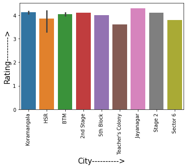

```python
sns.barplot(data['City Name'],data['Rating'])
plt.xticks(rotation=90)
plt.xlabel('City---------->',fontsize = 15)
plt.ylabel('Rating--------->',fontsize = 15)
plt.show()
```

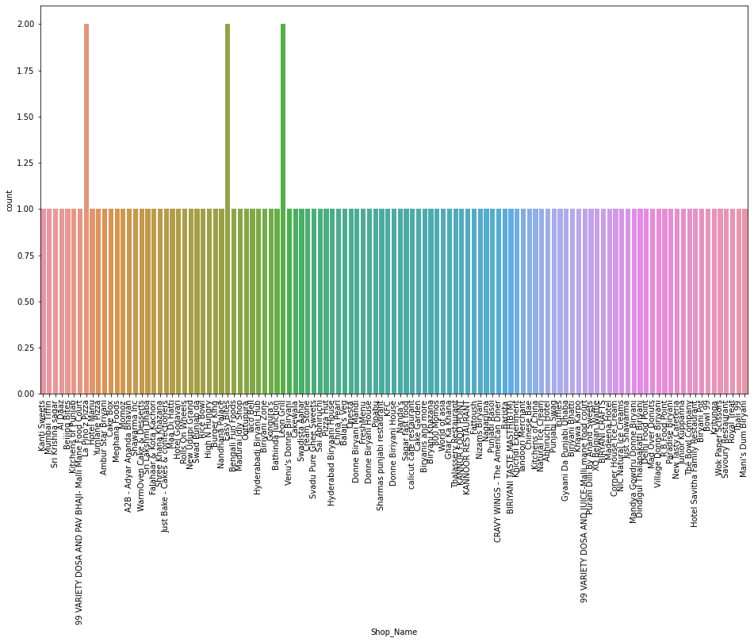

```python
plt.figure(figsize=(16,9))
sns.countplot(df['Shop_Name'])
plt.xticks(rotation=90)
plt.show()
```

```python
df['City'] = data['City Name']
```

```python
df
```

|  | Shop_Name | Cuisine | Location | Rating | Cost_for_Two | City |
| --- | --- | --- | --- | --- | --- | --- |
| 0 | Kanti Sweets | Sweets | Koramangala, Koramangala | 4.3 | 150 | Koramangala |
| 1 | Mumbai Tiffin | North Indian, Home Food, Thalis, Combo | Sector 5, HSR | 4.4 | 400 | HSR |
| 2 | Sri Krishna sagar | South Indian, North Indian, Fast Food, Beverag... | 6th Block, Koramangala | 4.1 | 126 | Koramangala |
| 3 | Al Daaz | American, Arabian, Chinese, Desserts, Fast Foo... | HSR, HSR | 4.4 | 400 | HSR |
| 4 | Beijing Bites | Chinese, Thai | 5th Block, Koramangala | 4.1 | 450 | Koramangala |
| ... | ... | ... | ... | ... | ... | ... |
| 113 | Wok Paper Scissors | Pan-Asian, Chinese, Asian | JNC Road, Koramangala | 3.9 | 219 | Koramangala |
| 114 | Savoury Restaurant | Arabian, Middle Eastern, North Indian, Grill, ... | Madiwala, BTM | 4.1 | 600 | BTM |
| 115 | Royal Treat | North Indian, Chinese, Seafood, Biryani | 5th block Koramangala, Koramangala | 4.2 | 193 | Koramangala |
| 116 | Thali 99 | North Indian | Koramangala, Koramangala | 4.3 | 200 | Koramangala |
| 117 | Mani's Dum Biryani | Andhra, Biryani | 1st Block, Koramangala | 4.2 | 400 | Koramangala |

118 rows × 6 columns

```python
df.drop('City',axis = 1,inplace=True)
```

```python
df
```

|  | Shop_Name | Cuisine | Location | Rating | Cost_for_Two |
| --- | --- | --- | --- | --- | --- |
| 0 | Kanti Sweets | Sweets | Koramangala, Koramangala | 4.3 | 150 |
| 1 | Mumbai Tiffin | North Indian, Home Food, Thalis, Combo | Sector 5, HSR | 4.4 | 400 |
| 2 | Sri Krishna sagar | South Indian, North Indian, Fast Food, Beverag... | 6th Block, Koramangala | 4.1 | 126 |
| 3 | Al Daaz | American, Arabian, Chinese, Desserts, Fast Foo... | HSR, HSR | 4.4 | 400 |
| 4 | Beijing Bites | Chinese, Thai | 5th Block, Koramangala | 4.1 | 450 |
| ... | ... | ... | ... | ... | ... |
| 113 | Wok Paper Scissors | Pan-Asian, Chinese, Asian | JNC Road, Koramangala | 3.9 | 219 |
| 114 | Savoury Restaurant | Arabian, Middle Eastern, North Indian, Grill, ... | Madiwala, BTM | 4.1 | 600 |
| 115 | Royal Treat | North Indian, Chinese, Seafood, Biryani | 5th block Koramangala, Koramangala | 4.2 | 193 |
| 116 | Thali 99 | North Indian | Koramangala, Koramangala | 4.3 | 200 |
| 117 | Mani's Dum Biryani | Andhra, Biryani | 1st Block, Koramangala | 4.2 | 400 |

118 rows × 5 columns

```python
df['City'] = b['City Name']
```

```python
df
```

|  | Shop_Name | Cuisine | Location | Rating | Cost_for_Two | City |
| --- | --- | --- | --- | --- | --- | --- |
| 0 | Kanti Sweets | Sweets | Koramangala, Koramangala | 4.3 | 150 | Koramangala |
| 1 | Mumbai Tiffin | North Indian, Home Food, Thalis, Combo | Sector 5, HSR | 4.4 | 400 | HSR |
| 2 | Sri Krishna sagar | South Indian, North Indian, Fast Food, Beverag... | 6th Block, Koramangala | 4.1 | 126 | Koramangala |
| 3 | Al Daaz | American, Arabian, Chinese, Desserts, Fast Foo... | HSR, HSR | 4.4 | 400 | HSR |
| 4 | Beijing Bites | Chinese, Thai | 5th Block, Koramangala | 4.1 | 450 | Koramangala |
| ... | ... | ... | ... | ... | ... | ... |
| 113 | Wok Paper Scissors | Pan-Asian, Chinese, Asian | JNC Road, Koramangala | 3.9 | 219 | Koramangala |
| 114 | Savoury Restaurant | Arabian, Middle Eastern, North Indian, Grill, ... | Madiwala, BTM | 4.1 | 600 | BTM |
| 115 | Royal Treat | North Indian, Chinese, Seafood, Biryani | 5th block Koramangala, Koramangala | 4.2 | 193 | Koramangala |
| 116 | Thali 99 | North Indian | Koramangala, Koramangala | 4.3 | 200 | Koramangala |
| 117 | Mani's Dum Biryani | Andhra, Biryani | 1st Block, Koramangala | 4.2 | 400 | Koramangala |

118 rows × 6 columns

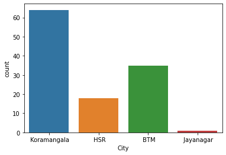

```python
sns.countplot(df['City'])
```

```python
avg_rating = df[df['City'] == 'Koramangala']['Rating']
```

```python
uniq_city = df['City'].unique()
```

```python
list1 = []
for i in uniq_city:
    avg = np.mean(df[df['City'] == i]['Rating'])
    list1.append(avg)
```

```python
list1
```

```
[4.126562500000001, 3.8444444444444446, 4.048571428571428, 4.3]
```

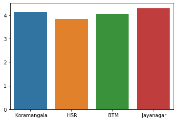

```python
sns.barplot(x=uniq_city, y=list1)
```

```python
list2 = []
for i in uniq_city:
    avg = np.sum(df[df['City'] == i]['Cost_for_Two'])
    list2.append(avg)
```

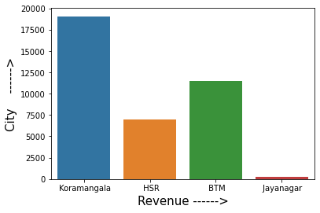

```python
sns.barplot(x=uniq_city, y=list2)
plt.xlabel('Revenue ------>',fontsize=15)
plt.ylabel('City    ------>',fontsize=15)
plt.show()
```

# Observation

Maximum Revenue is from Koramangala

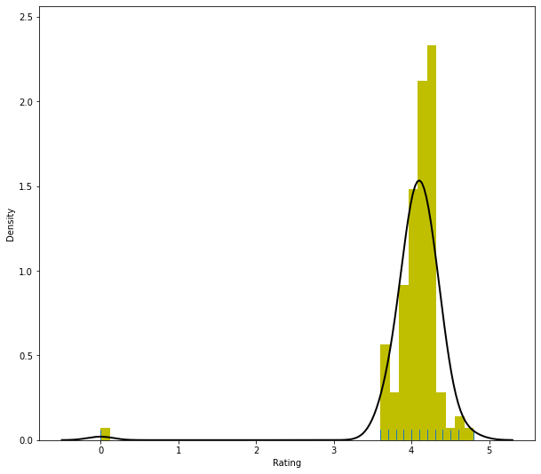

```python
plt.figure(figsize=(10,9))
sns.distplot(a=df['Rating'],kde_kws={"color": "k", "lw": 2, "label": "KDE"},
             hist_kws={"linewidth": 3,"alpha": 1, "color": "y"},rug = True)
plt.show()
```

# Conclusion:

1-> From this Distribution Plot, We can conclude that More that '50%' of Restaurants are having a Rating greater than 3.8 with a Maximum Rating of "4.8" which is considered as a decent Rating.

2-> And It also means that, Most of these Restaurants are doing very well & Rated accordingly by the Customers.

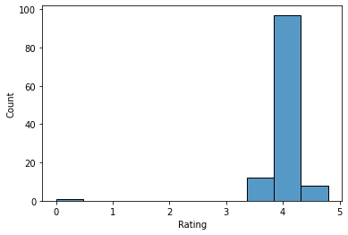

```python
sns.histplot(df['Rating'], bins = 10)
```

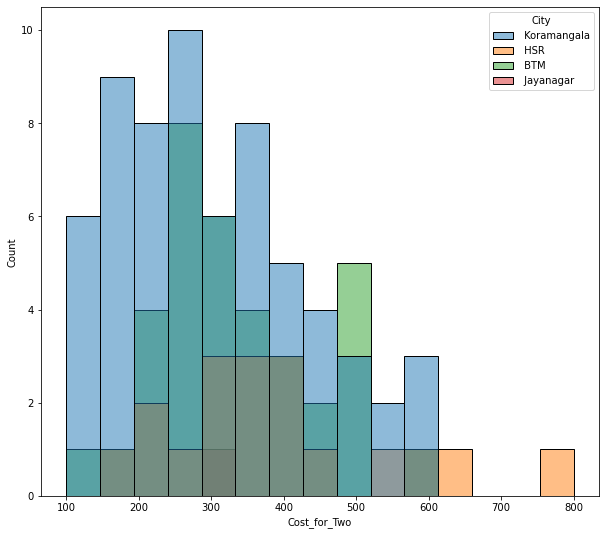

```python
plt.figure(figsize=(10,9))
sns.histplot(data=df,x='Cost_for_Two',bins = 15,hue='City', stat='count')
plt.show()
```

# Exporting New Processed Data to a location 'C:\Users\acer\Documents' as Swiggy

```python
df.to_csv('C:/Users/acer/Documents/Swiggy.csv')
```

# CUISINE ANALYSIS:

```python
df['Cuisine'] = df['Cuisine'].str.title()
df['Cuisine']
```

```
0                                                 Sweets
1                 North Indian, Home Food, Thalis, Combo
2      South Indian, North Indian, Fast Food, Beverag...
3      American, Arabian, Chinese, Desserts, Fast Foo...
4                                          Chinese, Thai
                             ...
113                            Pan-Asian, Chinese, Asian
114    Arabian, Middle Eastern, North Indian, Grill, ...
115              North Indian, Chinese, Seafood, Biryani
116                                         North Indian
117                                      Andhra, Biryani
Name: Cuisine, Length: 118, dtype: object
```

```python
freq_dict = {}
for i in df['Cuisine'].unique():
    Cuisines_Lists = i.split(',')
    for Cuisine in Cuisines_Lists:
        Cuisine = Cuisine.lstrip(' ')
        if Cuisine in freq_dict:
            freq_dict[Cuisine] = freq_dict[Cuisine] + 1
        else:
            freq_dict[Cuisine] = 1

print(freq_dict)
print()
print('Total Records: \t', len(freq_dict))
```

```
{'Sweets': 2, 'North Indian': 32, 'Home Food': 2, 'Thalis': 1, 'Combo': 1, 'South Indian': 23, 'Fast Food': 16, 'Beverages': 9, 'Jain': 2, 'American': 8, 'Arabian': 4, 'Chinese': 35, 'Desserts': 15, 'Mughlai': 7, 'Thai': 2, 'Italian': 4, 'Kerala': 6, 'Pizzas': 5, 'Mexican': 3, 'Andhra': 12, 'Seafood…

Total Records: 	 48
```

```python
Cuisine = freq_dict.keys()
freq = freq_dict.values()
```

```python
df_Cuisine_Analysis = pd.DataFrame()
```

```python
df_Cuisine_Analysis['Cuisine'] = Cuisine
df_Cuisine_Analysis['Count'] = freq
```

```python
df_Cuisine_Analysis
```

|  | Cuisine | Count |
| --- | --- | --- |
| 0 | Sweets | 2 |
| 1 | North Indian | 32 |
| 2 | Home Food | 2 |
| 3 | Thalis | 1 |
| 4 | Combo | 1 |
| 5 | South Indian | 23 |
| 6 | Fast Food | 16 |
| 7 | Beverages | 9 |
| 8 | Jain | 2 |
| 9 | American | 8 |
| 10 | Arabian | 4 |
| 11 | Chinese | 35 |
| 12 | Desserts | 15 |
| 13 | Mughlai | 7 |
| 14 | Thai | 2 |
| 15 | Italian | 4 |
| 16 | Kerala | 6 |
| 17 | Pizzas | 5 |
| 18 | Mexican | 3 |
| 19 | Andhra | 12 |
| 20 | Seafood | 8 |
| 21 | Biryani | 18 |
| 22 | Indian | 5 |
| 23 | Rajasthani | 1 |
| 24 | Bakery | 2 |
| 25 | Healthy Food | 4 |
| 26 | Hyderabadi | 5 |
| 27 | Snacks | 4 |
| 28 | Turkish | 2 |
| 29 | Portuguese | 2 |
| 30 | Chaat | 2 |
| 31 | Asian | 3 |
| 32 | Continental | 3 |
| 33 | Mediterranean | 1 |
| 34 | Lebanese | 1 |
| 35 | Cafe | 2 |
| 36 | Salads | 2 |
| 37 | Pastas | 1 |
| 38 | Punjabi | 2 |
| 39 | Juices | 2 |
| 40 | Kebabs | 2 |
| 41 | Grill | 2 |
| 42 | Ice Cream | 2 |
| 43 | Tandoor | 1 |
| 44 | Chettinad | 2 |
| 45 | Pan-Asian | 2 |
| 46 | Oriental | 1 |
| 47 | Middle Eastern | 1 |

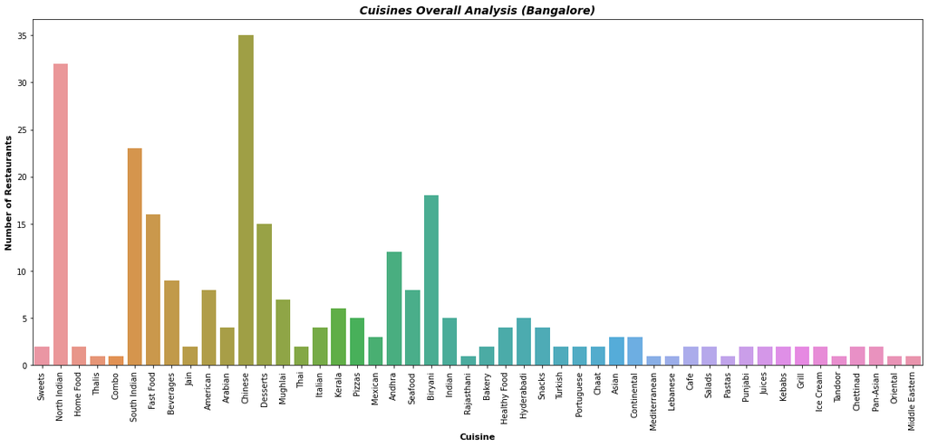

```python
plt.figure(figsize = (20, 8))
sns.barplot(x = df_Cuisine_Analysis['Cuisine'],
            y = df_Cuisine_Analysis['Count'],
            data = df_Cuisine_Analysis)
plt.xticks(rotation = 90)
plt.title('Cuisines Overall Analysis (Bangalore)', fontsize = 14, fontweight = 'bold', fontstyle = 'italic')
plt.xlabel('Cuisine', fontsize = 11, fontweight = 'bold')
plt.ylabel('Number of Restaurants', fontsize = 11, fontweight = 'bold')
plt.show()
```

```python
df_sort_cuisine = df_Cuisine_Analysis.sort_values(by='Count',ascending=False).iloc[:8]
df_sort_cuisine
```

|  | Cuisine | Count |
| --- | --- | --- |
| 11 | Chinese | 35 |
| 1 | North Indian | 32 |
| 5 | South Indian | 23 |
| 21 | Biryani | 18 |
| 6 | Fast Food | 16 |
| 12 | Desserts | 15 |
| 19 | Andhra | 12 |
| 7 | Beverages | 9 |

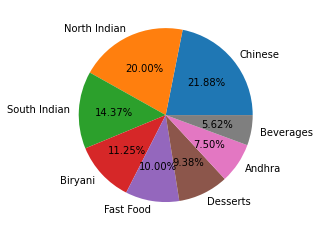

```python
plt.pie(df_sort_cuisine['Count'],labels=df_sort_cuisine['Cuisine'],autopct='%.2f%%')
plt.show()
```

# Conclusion:

# WordCloud Representation for Cuisines:

```python
df['Cuisine']
```

```
0                                                 Sweets
1                 North Indian, Home Food, Thalis, Combo
2      South Indian, North Indian, Fast Food, Beverag...
3      American, Arabian, Chinese, Desserts, Fast Foo...
4                                          Chinese, Thai
                             ...
113                            Pan-Asian, Chinese, Asian
114    Arabian, Middle Eastern, North Indian, Grill, ...
115              North Indian, Chinese, Seafood, Biryani
116                                         North Indian
117                                      Andhra, Biryani
Name: Cuisine, Length: 118, dtype: object
```

```python
df_Swiggy_Text = ', '.join(df['Cuisine'])
df_Swiggy_Text
```

```
'Sweets, North Indian, Home Food, Thalis, Combo, South Indian, North Indian, Fast Food, Beverages, Jain, American, Arabian, Chinese, Desserts, Fast Food, Mughlai, North Indian, Chinese, Thai, North Indian, Fast Food, North Indian, Chinese, Italian, South Indian, Kerala, Chinese, North Indian, Pizzas…
```

```python
from wordcloud import WordCloud
```

```python
import nltk
from nltk.corpus import stopwords
```

```python
import warnings
warnings.filterwarnings(action = 'ignore')
```

```python
stopwords_ENG = set(stopwords.words('english'))
stopwords_ENG
```

[output not shown]

[output cut: 124 more lines]

[output not shown]

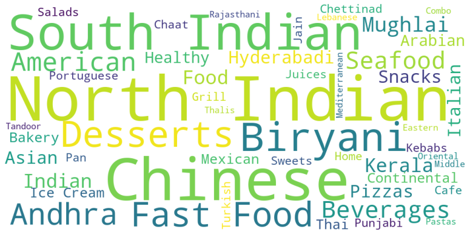

```python
wordcloud = WordCloud(width = 1000, height = 500, stopwords = stopwords_ENG, background_color = 'white').generate(df_Swiggy_Text)
plt.figure(figsize = (22, 7))
plt.imshow(wordcloud)
plt.axis('off')
plt.show()
```

```python
# Save the Image in the 'img' Folder:
wordcloud.to_file("C:/Users/acer/Pictures/Cuisines.png")
```

```
<wordcloud.wordcloud.WordCloud at 0x1cabd343280>
```